# Activity 2 — Task 3: Factorial ANOVA

Group 08

# 3 Inferential Statistics: Factorial ANOVA

## 3.1 Research Question and Hypotheses

This task addresses the first research question for Activity 2: **Does the rating of employer mental health concern (`Employer_Mental_Importance`) differ significantly between Male and Female employees, and does this difference vary depending on whether they work in a tech company or a non-tech company?**

To answer this, we formulate a Two-Way Factorial ANOVA with the following null hypotheses:

- **Main Effect A (Gender):** $H_0$: There is no difference in perceived mental health importance between Male and Female employees.
- **Main Effect B (Sector):** $H_0$: There is no difference in perceived mental health importance between tech and non-tech companies.
- **Interaction Effect:** $H_0$: The effect of gender on mental health importance ratings is consistent across both tech and non-tech companies (no interaction).

## 3.2 Data Preparation and Visualization

Because the research question strictly asks to compare “Men and Women”, we filter the dataset to include only these two explicit gender categories. This creates a clean $2 \times 2$ factorial design.

```r
library(tidyverse)
library(car)
library(knitr)

# Load data and filter strictly for Male and Female
data <- read.csv("dataset/osmi_clean_combined.csv") %>%
  filter(Gender_Category %in% c("Female", "Male")) %>%
  mutate(
    Gender_Category = factor(Gender_Category, levels = c("Male", "Female")),
    Tech_Company_Cat = factor(Tech_Company_Cat, levels = c("No", "Yes"))
  )

cat("Sample size for ANOVA:", nrow(data), "observations\n")
```

```
## Sample size for ANOVA: 989 observations
```

```r
# Calculate means for the interaction plot
interaction_data <- data %>%
  group_by(Gender_Category, Tech_Company_Cat) %>%
  summarise(Mean_Importance = mean(Employer_Mental_Importance, na.rm = TRUE), .groups = 'drop')

kable(interaction_data, digits = 2, caption = "Mean Employer Mental Importance by Group")
```

Mean Employer Mental Importance by Group

| Gender_Category | Tech_Company_Cat | Mean_Importance |
| --- | --- | --- |
| Male | No | 4.74 |
| Male | Yes | 5.08 |
| Female | No | 4.80 |
| Female | Yes | 5.29 |

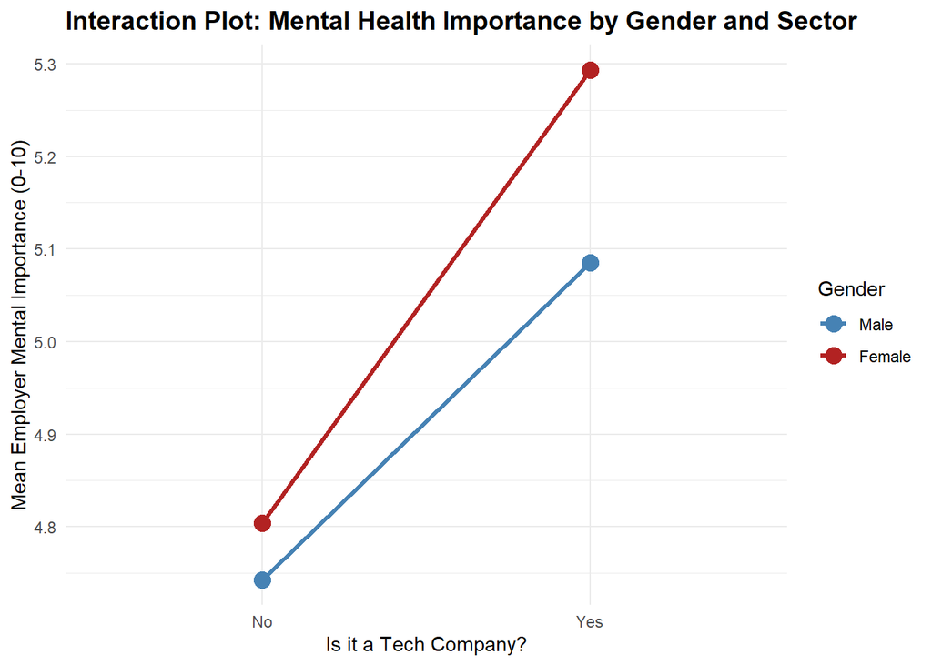

```r
# Interaction Plot
ggplot(interaction_data, aes(x = Tech_Company_Cat, y = Mean_Importance,
                             color = Gender_Category, group = Gender_Category)) +
  geom_line(linewidth = 1.2) +
  geom_point(size = 4) +
  scale_color_manual(values = c("Male" = "steelblue", "Female" = "firebrick")) +
  theme_minimal() +
  labs(
    title = "Interaction Plot: Mental Health Importance by Gender and Sector",
    x = "Is it a Tech Company?",
    y = "Mean Employer Mental Importance (0-10)",
    color = "Gender"
  ) +
  theme(plot.title = element_text(face = "bold", size = 14))
```

Visually, the interaction plot shows that tech companies score slightly higher on average than non-tech companies for both genders. Females appear to rate tech companies slightly higher than males do. However, the lines are nearly parallel, suggesting that a significant interaction effect is unlikely.

## 3.3 Assumption Testing

Before interpreting the ANOVA $F$-tests, we must check the assumptions of normality and equal variances (homoscedasticity). Since the design is unbalanced (we have more males than females, and more tech companies than non-tech), we must use **Type III Sums of Squares** and set orthogonal contrasts.

```r
# Set orthogonal contrasts for Type III ANOVA
options(contrasts = c("contr.sum", "contr.poly"))

# Fit the linear model
anova_model <- lm(Employer_Mental_Importance ~ Gender_Category * Tech_Company_Cat, data = data)

# 1. Normality Test (Shapiro-Wilk)
# Shapiro-Wilk rejects at N=989 because it is oversensitive to trivial departures on this bounded scale.
shapiro_res <- shapiro.test(resid(anova_model))

# 2. Homoscedasticity Test (Levene's Test)
levene_res <- car::leveneTest(Employer_Mental_Importance ~ Gender_Category * Tech_Company_Cat, data = data)

cat("Shapiro-Wilk Test for Normality:\n")
```

```
## Shapiro-Wilk Test for Normality:
```

```r
cat("W =", round(shapiro_res$statistic, 3), ", p-value =", signif(shapiro_res$p.value, 3), "\n\n")
```

```
## W = 0.979 , p-value = 8.12e-11
```

```r
cat("Levene's Test for Homoscedasticity:\n")
```

```
## Levene's Test for Homoscedasticity:
```

```r
cat("F =", round(levene_res$`F value`[1], 3), ", p-value =", round(levene_res$`Pr(>F)`[1], 3), "\n")
```

```
## F = 0.032 , p-value = 0.992
```

- **Normality fails (**$p < 0.001$): The Shapiro-Wilk test is highly sensitive at $N = 989$, so it rejects even trivial departures that are common with human survey data bounded on a 0-10 scale.
- **Homoscedasticity passes brilliantly (**$p = 0.992$): Unlike the salary data in Activity 1, the variance in survey responses is incredibly stable and equal across all four groups.

**Remedy Decision:** Because the variances are strictly equal (Levene’s test passes) and the sample size is large ($N = 989$), the Central Limit Theorem ensures that the standard $F$-test is highly robust against violations of normality. We can confidently proceed with the standard Type III ANOVA without needing a heteroscedasticity correction.

## 3.4 ANOVA Results and Interpretation

```r
# Type III ANOVA
anova_results <- car::Anova(anova_model, type = 3)
print(anova_results)
```

```
## Anova Table (Type III tests)
##
## Response: Employer_Mental_Importance
##                                   Sum Sq  Df   F value Pr(>F)
## (Intercept)                      18611.7   1 2796.6897 <2e-16 ***
## Gender_Category                      3.4   1    0.5123 0.4743
## Tech_Company_Cat                    32.4   1    4.8734 0.0275 *
## Gender_Category:Tech_Company_Cat     1.0   1    0.1534 0.6954
## Residuals                         6555.1 985
## ---
## Signif. codes:  0 '***' 0.001 '**' 0.01 '*' 0.05 '.' 0.1 ' ' 1
```

### 3.4.1 Main Findings

Based on the Type III ANOVA table, we conclude the following:

- **No Interaction Effect (**$p = 0.695$): The interaction between gender and the tech sector is not statistically significant. The slight widening of the gap seen in the interaction plot is purely due to random sample noise. The way men and women perceive their company’s mental health support does not fundamentally change whether they are inside or outside the tech sector.
- **No Significant Gender Difference (**$p = 0.474$): The main effect of gender is entirely non-significant. Male and Female employees perceive their employers’ prioritization of mental health almost identically.
- **Significant Sector Difference (**$p = 0.0275$): The main effect of the company sector is statistically significant at the 5% alpha level. Employees in tech companies rate their employers’ mental health support significantly higher (means $\approx$ 5.1 - 5.3) than employees in non-tech companies (means $\approx$ 4.7 - 4.8).

### 3.4.2 Estimated Marginal Means and Confidence Intervals

To quantify the significant sector effect, we report the Type III-adjusted estimated marginal means (EMMs) with 95% confidence intervals.

```r
library(emmeans)

# Type III-adjusted estimated marginal means for the sector main effect
emm_sector <- emmeans(anova_model, ~ Tech_Company_Cat)

sector_emm_tbl <- as.data.frame(emm_sector) %>%
  select(Tech_Company_Cat, emmean, SE, lower.CL, upper.CL) %>%
  mutate(across(c(emmean, SE, lower.CL, upper.CL), ~ round(.x, 2)))

kable(sector_emm_tbl,
      caption = "Estimated marginal means for company sector (95% CI)")
```

Estimated marginal means for company sector (95% CI)

| Tech_Company_Cat | emmean | SE | lower.CL | upper.CL |
| --- | --- | --- | --- | --- |
| No | 4.77 | 0.16 | 4.47 | 5.08 |
| Yes | 5.19 | 0.11 | 4.98 | 5.40 |

```r
# Pairwise contrast: tech (Yes) vs non-tech (No)
sector_diff <- as.data.frame(
  summary(pairs(emm_sector, reverse = TRUE), infer = c(TRUE, TRUE))
)

sector_est <- round(sector_diff$estimate[1], 2)
sector_lo  <- round(sector_diff$lower.CL[1], 2)
sector_hi  <- round(sector_diff$upper.CL[1], 2)
sector_p   <- format.pval(sector_diff$p.value[1], digits = 3, eps = 0.001)

kable(
  sector_diff[, c("contrast", "estimate", "SE", "lower.CL", "upper.CL", "p.value")] %>%
    mutate(across(c(estimate, SE, lower.CL, upper.CL), ~ round(.x, 2))),
  caption = "Pairwise sector contrast (tech vs non-tech)"
)
```

Pairwise sector contrast (tech vs non-tech)

| contrast | estimate | SE | lower.CL | upper.CL | p.value |
| --- | --- | --- | --- | --- | --- |
| Yes - No | 0.42 | 0.19 | 0.05 | 0.79 | 0.0275028 |

```r
# Scalars for inline text
emm_sector_df <- as.data.frame(emm_sector)
emm_no  <- round(emm_sector_df$emmean[1], 2)
emm_yes <- round(emm_sector_df$emmean[2], 2)
no_lo   <- round(emm_sector_df$lower.CL[1], 2)
no_hi   <- round(emm_sector_df$upper.CL[1], 2)
yes_lo  <- round(emm_sector_df$lower.CL[2], 2)
yes_hi  <- round(emm_sector_df$upper.CL[2], 2)

# Partial eta-squared for the significant sector effect
partial_eta_sector <- anova_results["Tech_Company_Cat", "Sum Sq"] /
  (anova_results["Tech_Company_Cat", "Sum Sq"] +
     anova_results["Residuals", "Sum Sq"])
```

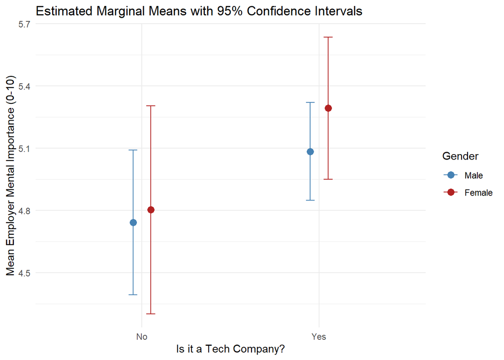

```r
emm_cells <- as.data.frame(emmeans(anova_model, ~ Gender_Category * Tech_Company_Cat))

ggplot(emm_cells, aes(x = Tech_Company_Cat, y = emmean, color = Gender_Category)) +
  geom_point(size = 3, position = position_dodge(width = 0.2)) +
  geom_errorbar(aes(ymin = lower.CL, ymax = upper.CL), width = 0.1,
                position = position_dodge(width = 0.2)) +
  scale_color_manual(values = c("Male" = "steelblue", "Female" = "firebrick")) +
  theme_minimal() +
  labs(
    title = "Estimated Marginal Means with 95% Confidence Intervals",
    x = "Is it a Tech Company?",
    y = "Mean Employer Mental Importance (0-10)",
    color = "Gender"
  )
```

Tech-company employees rate employer mental-health importance at **5.19** (95% CI: [4.98, 5.4]) versus **4.77** (95% CI: [4.47, 5.08]) for non-tech employees. The tech-non-tech gap is **0.42 points** (95% CI: [0.05, 0.79], $p = 0.0275$), and the confidence interval for the difference excludes zero, confirming the significance. Because the interaction was non-significant, this sector advantage applies equally to male and female employees — the plot shows their confidence intervals tracking consistently, rather than crossing. The partial $\eta^2$ of **0.005** indicates a small effect: the sector difference is reliable but explains only a modest share of the variance in perceived mental-health support.

### 3.4.3 Tukey HSD Multiple Comparisons

As a check against inflated false positives, we additionally run Tukey’s HSD, which controls the family-wise error rate across all pairwise comparisons. This verifies that the sector difference survives the correction and that no single gender-sector cell drives it.

```r
aov_model <- aov(Employer_Mental_Importance ~ Gender_Category * Tech_Company_Cat, data = data)
tukey <- TukeyHSD(aov_model)

tukey_raw <- bind_rows(lapply(names(tukey), function(term) {
  m <- as.data.frame(tukey[[term]])
  m$Term <- term
  m$Comparison <- rownames(m)
  m
})) %>%
  mutate(Significant = `p adj` < 0.05)

tukey_tbl <- tukey_raw %>%
  mutate(across(c(diff, lwr, upr), ~ round(.x, 3)),
         `p adj` = format.pval(`p adj`, digits = 3, eps = 0.001))

kable(tukey_tbl, caption = "Tukey HSD family-wise comparisons (95% CI)")
```

Tukey HSD family-wise comparisons (95% CI)

|  | diff | lwr | upr | p adj | Term | Comparison | Significant |
| --- | --- | --- | --- | --- | --- | --- | --- |
| Female-Male | 0.160 | -0.184 | 0.504 | 0.3620 | Gender_Category | Female-Male | FALSE |
| Yes-No | 0.390 | 0.044 | 0.737 | 0.0273 | Tech_Company_Cat | Yes-No | TRUE |
| Female:No-Male:No | 0.061 | -0.740 | 0.862 | 0.9973 | Gender_Category:Tech_Company_Cat | Female:No-Male:No | FALSE |
| Male:Yes-Male:No | 0.342 | -0.211 | 0.895 | 0.3837 | Gender_Category:Tech_Company_Cat | Male:Yes-Male:No | FALSE |
| Female:Yes-Male:No | 0.551 | -0.091 | 1.193 | 0.1218 | Gender_Category:Tech_Company_Cat | Female:Yes-Male:No | FALSE |
| Male:Yes-Female:No | 0.281 | -0.446 | 1.008 | 0.7522 | Gender_Category:Tech_Company_Cat | Male:Yes-Female:No | FALSE |
| Female:Yes-Female:No | 0.490 | -0.307 | 1.286 | 0.3892 | Gender_Category:Tech_Company_Cat | Female:Yes-Female:No | FALSE |
| Female:Yes-Male:Yes | 0.209 | -0.337 | 0.755 | 0.7591 | Gender_Category:Tech_Company_Cat | Female:Yes-Male:Yes | FALSE |

```r
# Scalars for inline text
hsd_row <- tukey_raw[tukey_raw$Term == "Tech_Company_Cat", ]
hsd_diff <- round(hsd_row$diff, 2)
hsd_lo   <- round(hsd_row$lwr, 2)
hsd_hi   <- round(hsd_row$upr, 2)
hsd_p    <- format.pval(hsd_row$`p adj`, digits = 3, eps = 0.001)
```

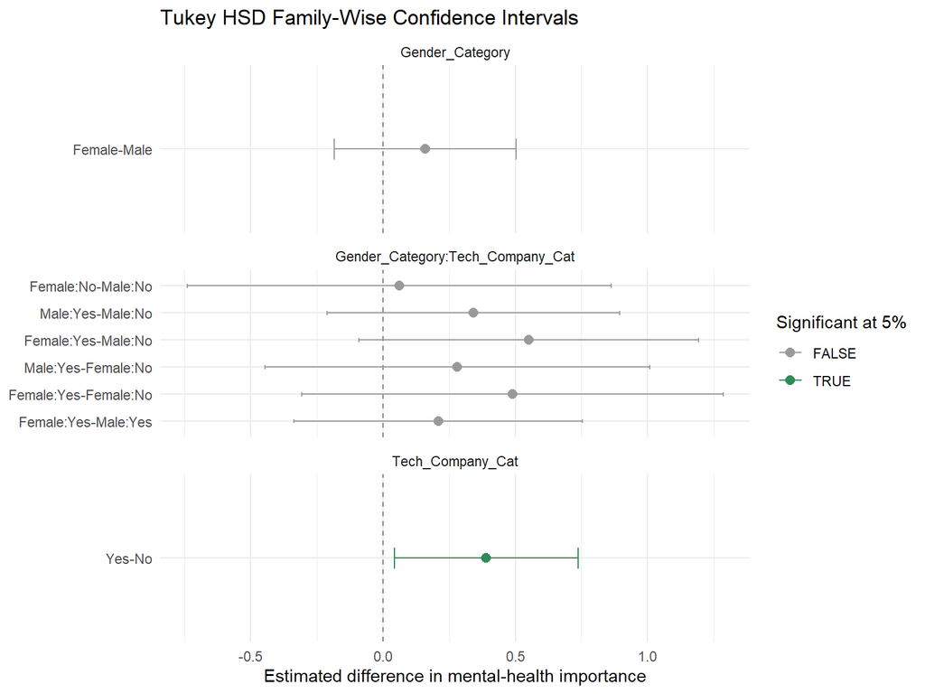

```r
tukey_plot_df <- tukey_raw %>%
  mutate(Comparison = factor(Comparison, levels = rev(Comparison)))

ggplot(tukey_plot_df, aes(x = diff, y = Comparison, color = Significant)) +
  geom_vline(xintercept = 0, linetype = "dashed", color = "grey50") +
  geom_point(size = 2.5) +
  geom_errorbar(aes(xmin = lwr, xmax = upr), orientation = "y", width = 0.15) +
  scale_color_manual(values = c("FALSE" = "grey60", "TRUE" = "seagreen")) +
  facet_wrap(~Term, scales = "free_y", ncol = 1) +
  theme_minimal() +
  labs(
    title = "Tukey HSD Family-Wise Confidence Intervals",
    x = "Estimated difference in mental-health importance", y = NULL,
    color = "Significant at 5%"
  )
```

The plot highlights **1** significant comparison(s): the sector pair **Yes - No** is the only one whose 95% family-wise interval excludes zero (difference = **0.39**, 95% CI: [0.04, 0.74], $p_{adj} = 0.0273$), in agreement with the Type III $F$-test. None of the six gender-sector cell comparisons are significant (all $p_{adj} > 0.1$), confirming that the tech advantage is a consistent offset shared by both male and female employees rather than an artifact of any single cell, and the gender pair remains non-significant ($p_{adj} = 0.362$).

**Conclusion:**

Employees across the board rate their employers’ focus on mental health at a relatively mediocre midpoint (around 5 out of 10). However, the technology sector is performing significantly better than traditional, non-tech industries in the eyes of their workers. Strikingly, this perception is universal across genders—male and female employees experience and report this exact same trend without bias.